# St Helena Island, grim past but a perfect day out - Brismania

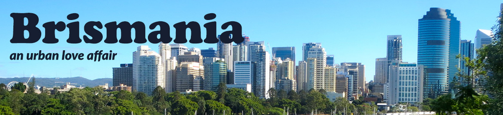

Brismania

# Day 148: Captive audience

By

[Brismania](https://brismania.com/author/bris_admin/)

-

Aug 6, 2019

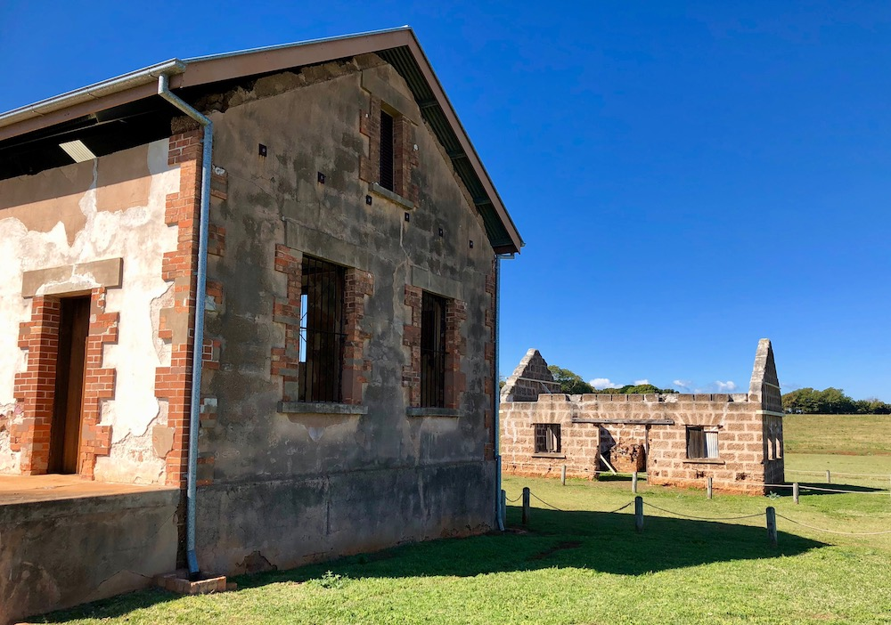

For the poor souls incarcerated on St Helena Island it was hell on earth, but a century later it’s a picturesque destination with fascinating remnants of its past.

For 65 years, St Helena was the scene of some brutal business, but these days it’s a historic national park (Queensland’s first when it was declared in October 1979) that provides excellent motivation to take a trip into Moreton Bay.

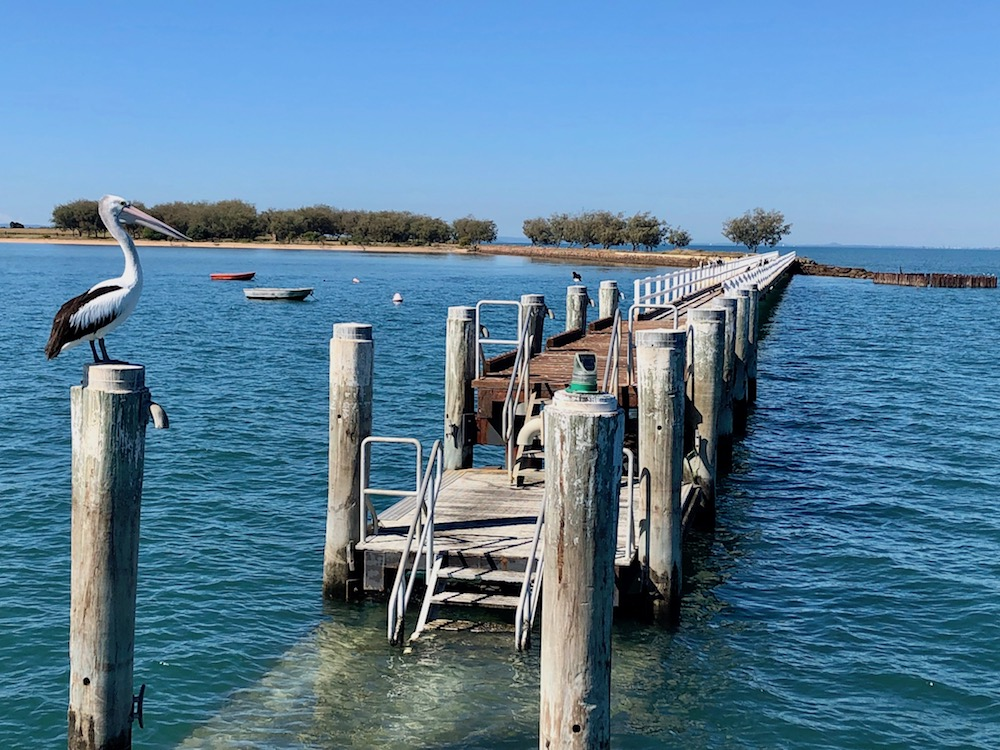

A new jetty was built in 1988 to link up to the causeway built by prisoners more than a century earlier.

St Helena is a pleasant 30-minute cruise from Manly on the *Cat o’ Nine Tails* tour which is the best way to see the island.

This is because access to most of the prison ruins is by guided tour only, and also, this team brings history to life, led by suitably attired “prisoners” and their “guard” Andre who has many a good yarn to tell about Brisbane history generally and St Helena specifically.

Almost immediately he sets the record straight. St Helena never was a place for convicts.

It opened in 1867 as Queensland’s first penal establishment to house long-term, high-security male prisoners who were crowded into cells at Petrie Terrace and spilling into the hulk *Proserpine* moored in the Brisbane River.

Next, we learn that Captain Cook planned to name the bay after Lord Morton who had funded his trip, but inadvertently added an “E”. This was copied by Matthew Flinders three decades later, and it stuck.

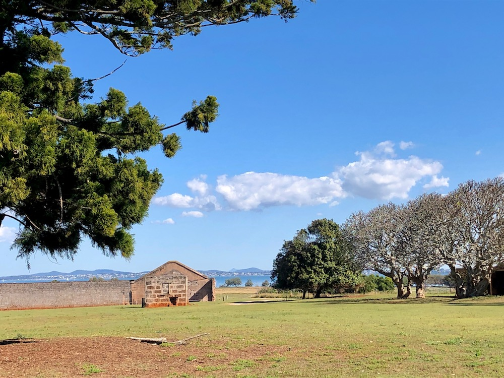

A beautiful setting within view of the mainland where ruins are the only reminder of its grim past.

Flinders, the story goes, imaginatively named the first verdant Moreton Bay island he saw Green Island. He then proceeded to name the others in the group Green Island 2 and Green Island 3 (King Island).